# Project1

Thomas Smale

# Introduction

California has had our largest fires in recorded history the last 2 years. Fires have had an effect on everyone in California weather it be due to air quality, or loss of property and loved ones. One school morning I woke up to a sky full of dark smoke, the smoke was so bad I could barely see down the block. Since that day in Chico there have been multiple other instances where smoke has blanketed the skies of California and ash has fallen from the skies. Smoke over the horizon is a terrible feeling as life as you know it can rapidly change without there being anything you can do about it. As a data science student, we are often just on our computer but we are learning complex skills which we can apply to the real world to make a difference. This project is a great opportunity to spend our time helping in the effort to solve current real world problems.

## Goal

I will be exploring this fire perimeter dataset to learn more about what measures cal fire is taking to combat fires. I would like to see if I can tell if any of these measures have been successful or unsuccessful. In addition I would like to see what is causing these fires in California. I would like to see just how many acres are burning and what areas have been affected the most.

My initial data science questions are

1. Can I see what regions are the most fire prone?
2. Which agencies respond to the most fires? Are any troops under resourced?
3. What were some of the biggest fires?
4. How long does it take for fires to be contained?
5. Did CalFire do enough prevention for the next fire season?
6. Are no burn days effective in preventing human caused fires?

## CalFire

I am using the 2020 California Fire Perimeters data set available from gis.data.gov. A fire perimeter is the boundary of a fire. This data set includes prescribed burns and wildfire perimeters dating back to 1950 for CAL FIRE. Data from 2021 is not released until the fire season is over, which is on going. The USFS has submitted records as far back as 1878 and the NPS has submitted records from as far back as 1921. A couple important notes about the data is that from 1950 to 2001 it included USFS fires 10 acres and greater and CAL FIRE fires 300 acres and greater. BLM and NPS started inputting data since 2002 collecting fires 10 acres and greater. From 2002-2014 CAL FIRE expanded its criteria by including timber fires 10 acres or greater, brush fires 50 acres and greater, grass fires 300 acres and greater in size, wild land fires destroying 3 or more structures, and wild land fires causing 300,000 or more in damage. From 2014 and on the monetary requirement was dropped and the damage requirement is 3 or more habitable structures or commercial structures. In 1989 each unit was assigned to verify all 300 plus Acre fires from pre 1989 and as a result there is a statewide GIS layer from 1950-1999. Some errors that could occur when exploring this data is that duplicates may exist. For example, USFS and CAL FIRE could both capture the fire perimeter and submit it. In some cases they could even report different parameters of the same fire. While duplicate records is rare, there is an asterisk next to the cells that are the most accurate. Here is an explanation of the variables from this data set.

- `OBJECTID`
- `YEAR` This dates back to data from 1950, with data from years before 2020 maybe only containing fires greater than 5000 acres.
- `STATE` While this data set is from CALFIRE possible states are Nevada, Oregon, Arizona, and California.
- `AGENCY` Different services may respond to the fires depending on jurisdiction. These services provide data to Cal Fire as a courtesy Different values we may see are CDF for California Department of Forestry and Fire Protection (Cal Fire), United States Forest Service (USFS), Bureau of Land Management (BLM), National Park Service (NPS), Contract Country (CC), Other FED (Federal Fire Protection Agency).
- `UNIT_ID` This is a series of digits to uniquely identify what units are responding to the fire.
- `FIRE_NAME` Fires are often named for geographic location or nearby landmarks like roads, lakes, rivers, and mountains.
- `INC_NUM` Number assigned by thee Emergency Command Center of the responsible agency for the fire
- `ALARM_DATE` The date the fire was brought to the attention of CALFIRE.
- `CONT_DATE` The date the fire was contained. A fire is 100% contained when a perimeter has been formed around the fire that will prevent it from spreading beyond the line. To form the perimeter fire fighters may use trenches (normally 10-12 feet and shallow), natural barriers like rivers, or even already burned patches of land. Once a fire is contained it may still be burning but within the perimeter.
- `CAUSE` An enumeration of values 1-19 for the reason the fire started. Enumeration 4 is campfire but enumeration 19 is illegal alien campfire which is confusing. Another confusing enumeration is 12 and 13 for firefighter training and non-firefighter training. Wouldn’t every fire that wasn’t firefighter training fall under this category of non-firefighter training. Interesting enumerations is 18 for escaped prescribed burn, 17 volcanic, 11 power line, 7 arson, 14 unknown, and 16 aircraft.
- `COMMENTS` Miscellaneous comments that can provide more information about the fire.
- `REPORT_AC` Estimated area consumed in fire. Units are in acres.
- `GIS_ACRES` GIS is a geographic information system that uses information from satellites to make inferences. I wonder if there are discrepancies between GIS_ACRES and the REPORT_AC.
- `C_METHOD` The method used to collect perimeter data. C stands for collection here. This is a range of digits from 1-8 that can be GPS, infrared, photos, hand drawn, or mixed collection methods.
- `OBJECTIVE` Either 1 suppression (wildfire) or 2 resource benefit (WFU). A WFU is allowing naturally ignited wild land fires like those started by lightning or lava to burn when in inaccessible terrain where people are not threatened. This is to avoid putting firefighters at risk and keep the land healthy.
- `FIRE_NUM` This has no description is unclear at the moment. It is probably a method used identify fires. There is not much research on it either, this will mostly be ignored.
- `SHAPE_Length` This is most likely GIS data. These map units are based on the coordinate system it could be square meters or something else. It could also be angular or linear.
- `SHAPE_Area` The units are unknown.

Summaries of the individual variables:

```r
library(tidyverse)
fires <- read.csv('~/classroom/csci385/California_Fire_Perimeters_(all).csv')
names(fires) <- tolower(names(fires))
fires <- rename(fires, year=year_)
fires <- select(fires, -objectid)
sum(is.na(fires))
```

```
## [1] 25100
```

Dealing with NA’s may be a difficult task here because the size of the data is so large. I will try to keep data concise so that I don’t have to change too many NA values to avoid convulating the data.

**year**

```r
years <- fires$year
range(years, na.rm = TRUE)
```

```
## [1] 1878 2020
```

```r
table(years)
```

```
## years
## 1878 1895 1896 1898 1900 1902 1903 1905 1906 1907 1908 1909 1910 1911 1912 1913
##    1    1    1    5   12    1    2    1    4   10   16   24   90  167   57   86
## 1914 1915 1916 1917 1918 1919 1920 1921 1922 1923 1924 1925 1926 1927 1928 1929
##  105  132  131  266  129  166  131  160  116  125  251   91  190   99  168  154
## 1930 1931 1932 1933 1934 1935 1936 1937 1938 1939 1940 1941 1942 1943 1944 1945
##  108  167  116   72  133   84  123   59  100  151   89  112  101  115  137  149
## 1946 1947 1948 1949 1950 1951 1952 1953 1954 1955 1956 1957 1958 1959 1960 1961
##  102  124   66  172  227  221  173  217  158  172  133  155  167  206  142  167
## 1962 1963 1964 1965 1966 1967 1968 1969 1970 1971 1972 1973 1974 1975 1976 1977
##  109   79  138   62  133  112  213  131  233  109  154  151  206  211  134  167
## 1978 1979 1980 1981 1982 1983 1984 1985 1986 1987 1988 1989 1990 1991 1992 1993
##  152  366  319  275  145  160  220  211  172  286  258  181  175   89  197  172
## 1994 1995 1996 1997 1998 1999 2000 2001 2002 2003 2004 2005 2006 2007 2008 2009
##  217  208  321  187  163  279  191  207  243  341  277  306  315  349  438  254
## 2010 2011 2012 2013 2014 2015 2016 2017 2018 2019 2020
##  209  317  351  298  238  318  352  607  413  312  500
```

CAL FIRE has data set going back to 1950 but USFS has data from 1878 in here. The two years with the most amount of data is 2017 and 2020 which has had the worse fires in recent history.

**state**

```r
states <- fires$state
unique(states)
```

```
## [1] "CA" "OR" "NV" "AZ" ""
```

```r
table(states)
```

```
## states
##          AZ    CA    NV    OR
##     3     1 21226    73    15
```

```r
select(fires, year, state) %>% filter(state != "CA" & year > 2000)
```

```
##    year state
## 1  2006    NV
## 2  2004    NV
## 3  2006    NV
## 4  2006    NV
## 5  2006    NV
## 6  2008    NV
## 7  2009    AZ
## 8  2012    OR
## 9  2013    NV
## 10 2014    OR
## 11 2014    NV
## 12 2014    NV
## 13 2014
## 14 2014
## 15 2016
```

```r
select(fires, year, state, agency) %>% filter(state != 'CA' & agency == 'CDF')
```

```
## [1] year   state  agency
## <0 rows> (or 0-length row.names)
```

```r
outside_state_fire <- select(fires, state, report_ac) %>% filter(state != 'CA')
summary(outside_state_fire$report_ac)
```

```
##     Min.  1st Qu.   Median     Mean  3rd Qu.     Max.     NA's
##    13.80    23.75   224.00 12195.08  4783.25 93071.00       80
```

I’m not expecting fires that happened outside of California to have any major impact on my analysis because there were so few fires outside of California included in this data set. Also, no fires that happened out of this state were under jurisdiction of Cal Fire which is who I am primarily interested in. We will also check back in later to see how the out of state fires size up with the in state ones. There is also a proportionally large number of NA’s for these out of state values probably because most of this data is older.

**agency**

```r
agencies <- fires$agency
unique(agencies)
```

```
##  [1] "CDF" "DOD" "CCO" "LRA" "BLM" "USF" "BIA" "NPS" "FWS" "OTH" ""
```

```r
fires %>% count(agency)
```

```
##    agency    n
## 1            5
## 2     BIA   12
## 3     BLM  652
## 4     CCO 3222
## 5     CDF 6563
## 6     DOD  163
## 7     FWS   22
## 8     LRA  111
## 9     NPS 1011
## 10    OTH    1
## 11    USF 9556
```

```r
agency_year <- fires %>% group_by(agency, year) %>% count()
arrange(agency_year, desc(agency_year$n)) %>% group_by(agency) %>% slice(1:3)
```

```
## # A tibble: 29 × 3
## # Groups:   agency [11]
##    agency  year     n
##    <chr>  <int> <int>
##  1 ""      2015     5
##  2 "BIA"   2018     4
##  3 "BIA"   2020     2
##  4 "BIA"   1996     1
##  5 "BLM"   1996    41
##  6 "BLM"   2012    41
##  7 "BLM"   2017    41
##  8 "CCO"   2017   131
##  9 "CCO"   2018   117
## 10 "CCO"   2020    90
## # … with 19 more rows
```

Surprisingly the United States Forest Service has been in charge of more fires than CalFire. Who is in charge of more land, what types of fires are these agencies typically responding to? Private (PVT) was an option of the official documentation but there appears to be no occurrences in this data set. Seems like the groups to pay the most attention to are BLM, CCO, CDF, LRA, NPS, and USF.

**unit_id**

```r
units <- fires$unit_id
unique(units) %>% length()
```

```
## [1] 91
```

```r
fires %>% group_by(unit_id) %>% count() %>% arrange(desc(n)) %>%
  filter(n > 10) %>% nrow()
```

```
## [1] 69
```

```r
unit_fires <- fires %>% group_by(unit_id, year) %>% drop_na() %>% count()
unit_fires <- rename(unit_fires, responses = n)
unit_fires %>% arrange(desc(responses)) %>% group_by(unit_id) %>% slice(1:1)%>%
  arrange(desc(responses))
```

```
## # A tibble: 81 × 3
## # Groups:   unit_id [81]
##    unit_id  year responses
##    <chr>   <int>     <int>
##  1 MEU      2008        62
##  2 VNC      2018        59
##  3 LNU      2020        55
##  4 SLU      2020        54
##  5 SHF      2008        51
##  6 KRN      2012        48
##  7 MNF      2003        35
##  8 MMU      2005        34
##  9 BBD      1996        33
## 10 SKU      2017        33
## # … with 71 more rows
```

```r
fires %>% group_by(unit_id) %>% top_n(1, report_ac) %>%
  select(year, unit_id, report_ac) %>% arrange(desc(report_ac))
```

```
## # A tibble: 87 × 3
## # Groups:   unit_id [87]
##     year unit_id report_ac
##    <int> <chr>       <dbl>
##  1  2002 PNF        499945
##  2  2018 LNU        410203
##  3  2020 SNF        379895
##  4  2012 NOD        315577
##  5  2017 VNC        281893
##  6  2003 CNF        280278
##  7  2013 STF        255858
##  8  2007 SBC        240207
##  9  2018 SHU        229651
## 10  1953 ANF        214500
## # … with 77 more rows
```

While a few units have especially a large number of responses to fires, the majority have responded to quite a few fires. I would like to see the year each unit responded to the most number of fires. I would also like to know which unit has responded to the biggest fires. Note some units biggest reported fire is less than 30 acres. I thought all fires reported by CAL FIRE were to be greater than 10, why are their biggest fires so small? It is interesting here to note the number of NA’s for report_ac. I had to remove all NA’s because for MRN it was showing up in the top 10 and year had NA.

**fire_name**

```r
fires %>% group_by(fire_name, report_ac) %>% arrange(desc(report_ac))
```

```
## # A tibble: 21,318 × 17
## # Groups:   fire_name, report_ac [13,423]
##     year state agency unit_id fire_name  inc_num  alarm_date   cont_date   cause
##    <int> <chr> <chr>  <chr>   <chr>      <chr>    <chr>        <chr>       <int>
##  1  2002 CA    USF    PNF     BISCUIT    00000000 2002/07/13 … "2002/11/0…     1
##  2  2018 CA    CDF    LNU     RANCH      00008646 2018/07/27 … "2018/09/1…    14
##  3  2020 CA    USF    SNF     CREEK      00001391 2020/09/04 … "2020/12/2…    14
##  4  2020 CA    USF    PNF     NORTH COM… 00001302 2020/08/17 … "2020/12/0…     1
##  5  2012 CA    BLM    NOD     RUSH       00003490 2012/08/12 … "2012/10/2…     1
##  6  2020 CA    CDF    LNU     HENNESSEY  00013337 2020/08/17 … "2020/09/1…     1
##  7  2017 CA    USF    VNC     THOMAS     00003583 2017/12/04 … "2018/01/1…     9
##  8  2003 CA    USF    CNF     CEDAR      00000000 2003/10/25 … "2003/11/0…     2
##  9  1993 CA    CCO    VNC     STECKEL    00000000 1993/10/27 … ""             14
## 10  2013 CA    USF    STF     RIM        00000006 2013/08/17 … "2013/10/2…     4
## # … with 21,308 more rows, and 8 more variables: comments <chr>,
## #   report_ac <dbl>, gis_acres <dbl>, c_method <int>, objective <int>,
## #   fire_num <chr>, shape_length <dbl>, shape_area <dbl>
```

```r
fires %>% group_by(fire_name) %>% count() %>% arrange(desc(n))
```

```
## # A tibble: 8,932 × 2
## # Groups:   fire_name [8,932]
##    fire_name        n
##    <chr>        <int>
##  1 " "           6565
##  2 "UKNOWN"        88
##  3 "N/A"           72
##  4 ""              51
##  5 "CANYON"        45
##  6 "RIVER"         39
##  7 "LAKE"          37
##  8 "CREEK"         35
##  9 "COTTONWOOD"    33
## 10 "BEAR"          32
## # … with 8,922 more rows
```

```r
fires %>% filter(fire_name == "AMERICAN")
```

```
##   year state agency unit_id fire_name  inc_num             alarm_date
## 1 1984    CA    USF     TNF  AMERICAN 00000000 1984/05/28 00:00:00+00
## 2 1997    CA    BLM     BBD  AMERICAN 00000000 1997/09/19 00:00:00+00
## 3 2000    CA    CDF     NEU  AMERICAN 00013624 2000/08/27 00:00:00+00
## 4 2013    CA    USF     TNF  AMERICAN 00000049 2013/08/10 00:00:00+00
## 5 2019    CA    CDF     LNU  AMERICAN 00018056 2019/10/06 00:00:00+00
##                cont_date cause comments report_ac   gis_acres c_method
## 1 1984/05/29 00:00:00+00     1                 21    28.03758       NA
## 2 1997/09/20 00:00:00+00    11               1944  1630.58760        8
## 3                           14                 NA   148.40906       NA
## 4 2013/10/08 00:00:00+00     9              27740 27430.52100        7
## 5 2019/10/07 00:00:00+00    14                 NA   526.85785        2
##   objective fire_num shape_length   shape_area
## 1         1 00000009     1944.013    -190695.1
## 2         1 0000D089    20434.922   -9901308.0
## 3         1 00000645     4820.292    -992007.0
## 4         1             81139.674 -184785600.2
## 5         1              8792.308   -3455730.1
```

```r
fire_names <- fires %>% filter(fire_name != " " | fire_name == "UNKNOWN") %>%
  group_by(fire_name) %>% drop_na()
total_duplicates <- 0
#This takes a while to compile, answer is 172 duplicates
# for (name in unique(fire_names$fire_name)) {
#   same_fire_name_df <- fire_names %>% filter(fire_name == name)
#   duplicates <- select(same_fire_name_df, year, agency, unit_id, fire_name) %>%
#     duplicated()
#   if(TRUE %in% duplicates) {
#     #Need plus one because first instance of duplicate is false
#     total_duplicates <- total_duplicates + sum(duplicates == TRUE) + 1
#   }
# }
# total_duplicates
fires %>% filter(fire_name == "CAMP" & year == 2018)
```

```
##   year state agency unit_id fire_name  inc_num             alarm_date
## 1 2018    CA    CDF     BTU      CAMP 00016737 2018/11/08 00:00:00+00
## 2 2018    CA    CDF     SLU      CAMP 00007640 2018/07/17 00:00:00+00
##                cont_date cause comments report_ac    gis_acres c_method
## 1 2018/11/26 00:00:00+00    11             153336 153335.56000        1
## 2 2018/07/17 00:00:00+00    11                 14     13.53527        1
##   objective fire_num shape_length    shape_area
## 1         1            405925.630 -1.051101e+09
## 2         1              1278.489 -8.323182e+04
```

Let’s see the names of the 5 biggest fires in California history. Are any fires named the same? Fires from the same years can have the same name. They can also share the same agency and unit_id. This is something to look out for. Something else to watch out for is that the entire fire names are not entered into the data set. So to find the Campfire in paradise, I had to look up only CAMP and then the year too because other fires are named camp.

**INC_NUM**

```r
inc_num <- fires$inc_num
paste("Length", length(inc_num))
```

```
## [1] "Length 21318"
```

```r
print(paste("NA values", sum(is.na(inc_num))))
```

```
## [1] "NA values 0"
```

```r
paste("Missing values", sum(inc_num == "" | inc_num == " "))
```

```
## [1] "Missing values 926"
```

```r
paste("Unique values", length(unique(inc_num)))
```

```
## [1] "Unique values 6325"
```

```r
#Note this is basically what I tried to do in above chunk. Improvement!
fires %>% group_by(inc_num) %>% summarise(n=n()) %>% arrange(desc(n))
```

```
## # A tibble: 6,325 × 2
##    inc_num        n
##    <chr>      <int>
##  1 "00000000" 12611
##  2 ""           922
##  3 "00312031"    27
##  4 "00312037"    21
##  5 "00USFS0F"    16
##  6 "00031000"    15
##  7 "004727"      14
##  8 "00312038"    13
##  9 "00000052"    11
## 10 "002067"      11
## # … with 6,315 more rows
```

```r
fires %>% select(inc_num, year, alarm_date) %>% filter(year == "2020") %>%
  arrange(alarm_date) %>% head()
```

```
##    inc_num year             alarm_date
## 1 00003783 2020 2020/01/21 00:00:00+00
## 2 00002399 2020 2020/02/12 00:00:00+00
## 3 00001401 2020 2020/02/15 00:00:00+00
## 4 00000141 2020 2020/02/17 00:00:00+00
## 5 00000087 2020 2020/02/17 00:00:00+00
## 6 00002023 2020 2020/02/22 00:00:00+00
```

While this column has no na values, it does have still have some missing values. All the other 25,000 NA values are in other columns. Some values are repeated let’s see what are repeated the most and when. So what is the big deal about inc_num why are there so many repeated values? I was able to find in older documentation that it is a consecutive number. However this doesn’t seem to be a value iterating from 0..X for 2020 or pre 1999 where I read that old documentation. I should be wary using this until I know more.

**alarm_date**

```r
library(lubridate)
fires %>% group_by(alarm_date) %>% summarise(n=n()) %>%
  arrange(desc(n)) %>% filter(alarm_date != "") %>% head()
```

```
## # A tibble: 6 × 2
##   alarm_date                 n
##   <chr>                  <int>
## 1 2008/06/21 00:00:00+00   122
## 2 1987/08/30 00:00:00+00    61
## 3 2003/09/03 00:00:00+00    56
## 4 2015/07/30 00:00:00+00    50
## 5 1999/08/23 00:00:00+00    47
## 6 2008/06/20 00:00:00+00    44
```

```r
#View(fires %>% filter(alarm_date == "2018/11/08 00:00:00+00"))
fires %>% select(alarm_date, report_ac, fire_name) %>%
  arrange(desc(report_ac)) %>% head()
```

```
##               alarm_date report_ac     fire_name
## 1 2002/07/13 00:00:00+00    499945       BISCUIT
## 2 2018/07/27 00:00:00+00    410203         RANCH
## 3 2020/09/04 00:00:00+00    379895         CREEK
## 4 2020/08/17 00:00:00+00    318776 NORTH COMPLEX
## 5 2012/08/12 00:00:00+00    315577          RUSH
## 6 2020/08/17 00:00:00+00    305651     HENNESSEY
```

```r
fires %>% group_by(alarm_date) %>% summarise(n=n()) %>%
  arrange(desc(n)) %>% filter(alarm_date != "") %>% head()
```

```
## # A tibble: 6 × 2
##   alarm_date                 n
##   <chr>                  <int>
## 1 2008/06/21 00:00:00+00   122
## 2 1987/08/30 00:00:00+00    61
## 3 2003/09/03 00:00:00+00    56
## 4 2015/07/30 00:00:00+00    50
## 5 1999/08/23 00:00:00+00    47
## 6 2008/06/20 00:00:00+00    44
```

```r
#Busiest months by number of reports
dates <- fires$alarm_date[fires$alarm_date != ""] %>%
  parse_datetime("%Y/%m/%d %H:%M:%S %z", na = c("", "NA"))
dates <- dates[!is.na(dates)]
months <- format(dates, "%m")
table(months)
```

```
## months
##   01   02   03   04   05   06   07   08   09   10   11   12
##  143  111  155  314  965 2495 3793 3555 2490 1194  515  224
```

```r
#4 methods to search by date
dates <- fires$alarm_date[fires$alarm_date != ""]
dates <- dates[!is.na(dates)]
fourth_july <- dates[substr(dates, 6, 10) == "06/04"]
mask <- fires$alarm_date %>% str_detect(regex(".06/04.", dotall=TRUE))
fourth_july <- fires$alarm_date[mask]
read <- fires %>% select(alarm_date) %>% ymd_hms(tz="UTC")
new_dates <- fires
new_dates$alarm_date <- as.Date(new_dates$alarm_date, "%Y/%m/%d")
#new_dates %>% group_by(alarm_date, fire_name) %>% arrange(desc(alarm_date))
#print(dates[dates > "2005/06/04" & dates < "2015/06/04"])
```

**cont_date**

```r
#Start with one instance
camp_fire <- fires %>%
  filter(fire_name == "CAMP" & alarm_date == "2018/11/08 00:00:00+00")
camp_fire
```

```
##   year state agency unit_id fire_name  inc_num             alarm_date
## 1 2018    CA    CDF     BTU      CAMP 00016737 2018/11/08 00:00:00+00
##                cont_date cause comments report_ac gis_acres c_method objective
## 1 2018/11/26 00:00:00+00    11             153336  153335.6        1         1
##   fire_num shape_length  shape_area
## 1              405925.6 -1051100904
```

```r
format <- "%Y/%m/%d %H:%M:%S %z"
difftime(camp_fire$alarm_date, camp_fire$cont_date, format)
```

```
## Time difference of -18 days
```

```r
times <- select(fires, alarm_date, cont_date, fire_name) %>%
  filter(!is.na(alarm_date) & alarm_date != "") %>%
  filter(!is.na(cont_date) & cont_date != "")
fire_duration <- difftime(times$cont_date, times$alarm_date, format, units="days")
fire_duration <- fire_duration[fire_duration >= 0 ]
cat("min = ", min(fire_duration), "max = ", max(fire_duration),
    "median = ", median(fire_duration),
    "quantile = ", quantile(fire_duration), "\n")
```

```
## min =  0 max =  3319 median =  1 quantile =  0 0 1 5 3319
```

I want to find out how long it takes for some fires to be contained once they are started. I want all the information one would see an a describe except for difference between start and cont date. There are about 25 observations where the fire is being reported as negative days longs. Going to throw out these values. These quantiles are misleading because while the 75% quantile is only 5 there are a thousand fires that have lasted more than 5 days. May want to filter out prescribed burns for this in the future

**cause**

```r
sort(table(fires$cause), decreasing=TRUE)
```

```
##
##   14    1    9    2    7    5   10   11    4    3    8   18    6   15   19   16
## 9543 3454 3379 1246  903  723  454  412  380  342  196   90   80   21   17   14
##   13   12
##   11    5
```

```r
df <- fires %>% group_by(year, cause) %>% filter(year >= "2000")
sort(table(df$cause), decreasing=TRUE)
```

```
##
##   14    1    2    9    7   10   11    5    4    8    3   18    6   15   19   16
## 1713 1614  779  778  410  403  327  284  185   93   59   57   46   17   17   13
##   13   12
##    6    2
```

```r
#fires %>% group_by(cause) %>% filter(cause == 12)
select(fires, cause, report_ac, fire_name) %>% filter(cause == 7) %>%
  arrange(desc(report_ac)) %>% head()
```

```
##   cause report_ac  fire_name
## 1     7    160371    STATION
## 2     7     97717       KING
## 3     7     91281        OLD
## 4     7     86000     KAWEAH
## 5     7     83323       FORK
## 6     7     59788 GRAND PRIX
```

Lets see what the leading causes for fires are. Shockingly the most often occurring cause is unknowns, we should check if this value changes for dates past 2000. Natural causes like lightning is the second most common. Number 3 is miscellaneous fires which can be categorized under multiple causes like lightning, equipment use, and campfires. After that there is a steep drop off to equipment use which is the fault of humans from activities like lawn mowing. We can see after the year 2000 the number of unknown fires falls but stays the same. Classification may have improved as miscellaneous decreases too. No fires in this data set are attributed to volcanoes, this is the only cause missing. Surprisingly, Arson is the 5th biggest cause of fires.

**comments**

```r
comments <- select(fires, comments) %>% filter(comments != "" & comments != " ")
comments <- drop_na(comments)
paste("max comment", comments %>% deparse() %>% nchar() %>% table() %>% max())
```

```
## [1] "max comment 260"
```

```r
mask <- deparse(comments) %>% nchar() == 260
```

Is there a length limit to the comments? The max length of a comment is 260 characters, comments are longer but they are cut off by an * indicating there is more to that comment somewhere. By reading comments interesting ones to me were “The cause was target shooting”, “… Total Cost 18,600,600”, “Children playing with fire”, and names of people.

**report_ac**

```r
fire_size <- fires$report_ac
fire_size <- fire_size[!is.na(fire_size)]
summary(fire_size)
```

```
##    Min. 1st Qu.  Median    Mean 3rd Qu.    Max.
##       0      15      60    2270     350  499945
```

```r
fires %>% filter(report_ac == 0) %>% group_by(year, report_ac) %>%
  unique() %>% count() %>% arrange(desc(n))  %>% head()
```

```
## # A tibble: 6 × 3
## # Groups:   year, report_ac [6]
##    year report_ac     n
##   <int>     <dbl> <int>
## 1  2017         0    82
## 2  2018         0    48
## 3  1934         0    13
## 4  1913         0    12
## 5  1925         0    11
## 6  1912         0     9
```

```r
#paste("Total acres burned ", sum(fire_size))
fires %>% filter(!is.na(report_ac)) %>% group_by(year) %>%
  summarise(report_ac = sum(report_ac)) %>%
  arrange(desc(report_ac)) %>% head()
```

```
## # A tibble: 6 × 2
##    year report_ac
##   <int>     <dbl>
## 1  2020  2386087.
## 2  2018  1385183.
## 3  2008  1306169.
## 4  2012  1012003.
## 5  2003   998634.
## 6  2007   995097.
```

Explanatory data analysis will be nice here to see the distribution of the fire sizes, trends in yearly median size of fires, and more. It is unclear to me why a value may be zero for the size of the fire other than it is unknown. This is surprising that so many zeros are reported in 2017 and 2018. For years dating back before 1950 I can understand. For reference 500,000 acres is equal to 780 square miles, a square mile being a square with sides of length 1 mile!!! The size of California in square miles is 163,696, Yosemite national park is 1169 square miles, and the size of New York is 302 square miles.

**GIS_ACRES**

```r
df <- select(fires, report_ac, gis_acres, year) %>% drop_na
summary(df$report_ac)
```

```
##    Min. 1st Qu.  Median    Mean 3rd Qu.    Max.
##       0      15      60    2283     350  499945
```

```r
summary(df$gis_acres)
```

```
##     Min.  1st Qu.   Median     Mean  3rd Qu.     Max.
##      0.0     17.4     72.2   2266.6    397.0 501082.0
```

```r
differences <- abs(df$report_ac - df$gis_acres)
paste("Differnce of over 100 acres", length(differences[differences > 100]))
```

```
## [1] "Differnce of over 100 acres 1202"
```

```r
differences_year <- df %>% filter(abs(report_ac - gis_acres) > 100) %>%
  count(year) %>% arrange(desc(n)) %>% head()
rename(differences_year, "Num large discrepencies" = "n")
```

```
##   year Num large discrepencies
## 1 1987                      74
## 2 2008                      43
## 3 1996                      37
## 4 2017                      35
## 5 2012                      34
## 6 2003                      33
```

Lets see differences between report_ac and GIS_ACRES. While most report_ac and GIS data are accurate there are certainly a good amount of astronomical differences in how many acres were burned. I will have to make a decision on which is more credible possibly row by row. May be handy when a report_ac is missing but this isn’t or vis versa.

**c_method**

```r
table(fires$c_method) %>% sort(decreasing=TRUE)
```

```
##
##    1    8    6    7    2    3    4    5
## 3302 2917 1085  768  585  185  165   89
```

```r
get_mode <- function(vec) {
  frequencies <- table(vec) %>% sort(decreasing=TRUE)
  strtoi(names(frequencies)[1])
}

c_method_yr <- fires %>% filter(!is.na(c_method) & c_method != 8) %>%
  group_by(year) %>%
  summarise(c_method = get_mode(c_method))
year <- fires %>% filter(year == "2020")
```

So throughout the course of time the main method of collection perimeter data has been GPS ground. It is a little suspect that the second most frequent collection method is unknown. Does this correlate with missing report_ac or gis_acres? I am also curious to know if the method of hand drawing has decreased with time because it is number 3. Also how other methods have changed with time. The total methods use would make a good pie chart. Some patterns we see is that from 1923-1980 the most popular collection method is hand drawing, 1980-2000 its other imagery, and from 2000 and on its ground GPS.

**objective**

```r
wildfire <- fires %>% filter(objective == 1)
resource <- fires %>% filter(objective == 2)
cat("Wildfire count ", length(wildfire$objective),
    "WFU ", length(resource$objective))
```

```
## Wildfire count  20851 WFU  272
```

```r
select(resource, fire_name, report_ac, objective) %>%
  arrange(desc(report_ac)) %>% head()
```

```
##       fire_name report_ac objective
## 1        CLOVER  15300.00         2
## 2      FERGUSON  10000.00         2
## 3          COMB   9753.94         2
## 4 SHEEP COMPLEX   9020.00         2
## 5   RATTLESNAKE   8419.00         2
## 6     WEST KERN   7963.00         2
```

This is very important because this shows weather or not a burn is prescribed or not. This will be an important factor in looking at wildfires. This is also a nice binary variable that can be used for prediction algorithms in part 2. While I thought there were going to be a lot of prescribed, resource burns in this set it is certainly not the case. Almost every fire is a wildfire. Also would be interesting to know difference in sizes of wildfires and WFU.

#### Vizzies

```r
library(gridExtra)
```

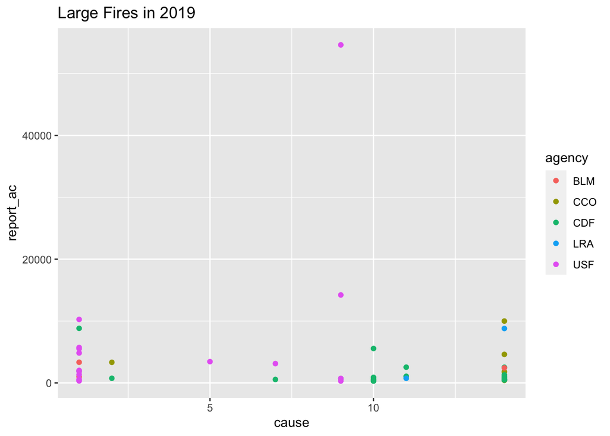

```r
library(grid)

# Lets start with data from 2019
fire_2020 <- fires %>% filter(year == "2019")

# Let's see fires 300 acres greater, and their causes
large_fires <- select(fire_2020, report_ac, cause, agency) %>%
  filter(report_ac > 300)
ggplot(large_fires, aes(x=cause, y=report_ac, color=agency)) +
  geom_point() +
  ggtitle("Large Fires in 2019")
```

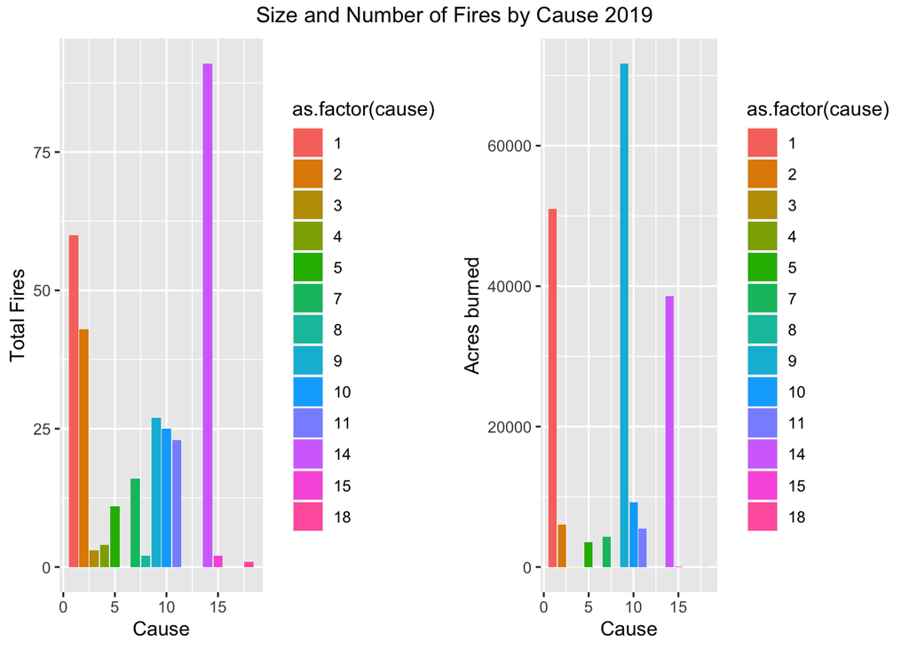

```r
# Number of fires and acres burned by cause
causes <- fire_2020 %>% filter(!is.na(report_ac)) %>%
  group_by(cause) %>%
  summarise(report_ac = sum(report_ac))
num_fires <- fire_2020 %>%
  group_by(cause) %>%
  summarise(count = n()) %>%
  drop_na()  %>%
  filter(cause != 16)
causes <- mutate(causes, fires = num_fires$count)
# I tried really hard to get this to display the meanings of the numbers
num<-ggplot(data=causes,  aes(x=cause, y=fires, fill=as.factor(cause))) +
  geom_bar(stat='identity') +
  xlab('Cause') + ylab('Total Fires')
# This doesn't display all causes because value of unknown so large
size<-ggplot(data=causes, aes(x=cause, y=report_ac,fill=as.factor(cause))) +
  geom_bar(stat='identity') +
  xlab('Cause') + ylab('Acres burned')
grid.arrange(num, size, nrow = 1, top="Size and Number of Fires by Cause 2019")
```

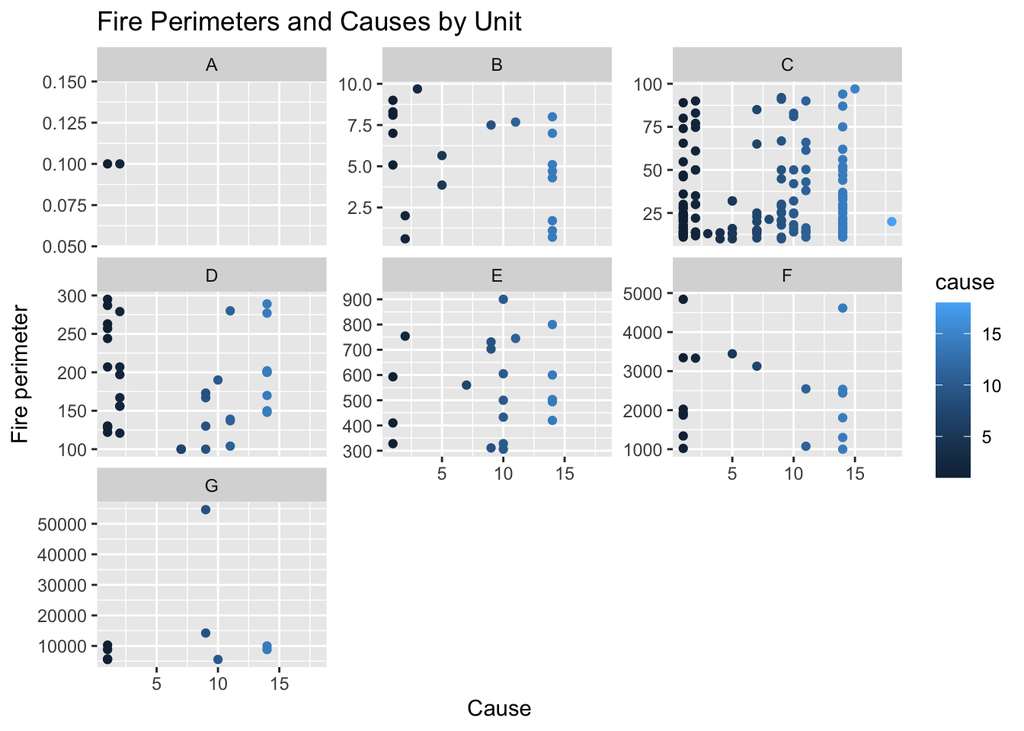

```r
# Number of fires by unit size
# Try to use facet split for this
fire_size <- fire_2020 %>% filter(!is.na(report_ac)) %>%
  select(year, report_ac, cause)
a <- filter(fire_size, report_ac <= .25)
b <- filter(fire_size, report_ac > .25 & report_ac <= 9.99)
c <- filter(fire_size, report_ac > 9.99 & report_ac <= 99)
d <- filter(fire_size, report_ac > 99 & report_ac <= 299)
e <- filter(fire_size, report_ac > 299 & report_ac <= 999)
f <- filter(fire_size, report_ac > 999 & report_ac <= 4999)
g <- filter(fire_size, report_ac > 4999)
# Merge and Join take WAY too long
# Want three columns, year, unit, and report_ac
get_unit <- function(vec, letter) {
  unit <- c()
  i <- 0
  while (i < length(vec)) {
    unit <- append(unit, letter, after=length(unit))
    i <- i + 1
  }
  unit
}
df<-data.frame(year = c(a$year, b$year, c$year, d$year, e$year, f$year, g$year),
               unit = c(get_unit(a$year, "A"), get_unit(b$year, "B"),
                        get_unit(c$year, "C"), get_unit(d$year, "D"),
                        get_unit(e$year, "E"), get_unit(f$year, "F"),
                        get_unit(g$year, "G")),
               report_ac = c(a$report_ac, b$report_ac, c$report_ac, d$report_ac,
                             e$report_ac, f$report_ac, g$report_ac),
               cause = c(a$cause, b$cause, c$cause, d$cause, e$cause, f$cause,
                         g$cause))
ggplot(data=df, aes(x=cause, y=report_ac, color=cause)) +
  geom_point() +
  xlab('Cause') + ylab('Fire perimeter') +
  facet_wrap(~unit, scales="free_y") +
  ggtitle("Fire Perimeters and Causes by Unit")
```

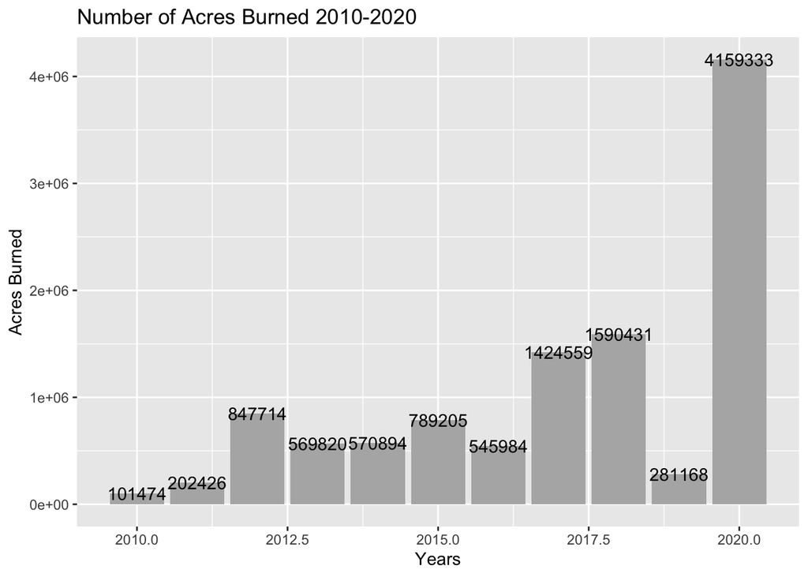

```r
# Number of acres burned 2010-2020
decade_fires <- fires %>% select(year, gis_acres) %>%
  filter(year >= "2010" & !is.na(gis_acres))
decade_fires_sum <- decade_fires %>% group_by(year) %>%
  summarise(gis_acres = sum(gis_acres))
decade_fires_sum$gis_acres <- as.integer(decade_fires_sum$gis_acres)
ggplot(decade_fires_sum, aes(x=year, y=gis_acres)) +
  geom_bar(stat="identity", fill="gray70") +
  geom_text(aes(label=gis_acres)) +
  xlab("Years") + ylab("Acres Burned") +
  ggtitle("Number of Acres Burned 2010-2020")
```

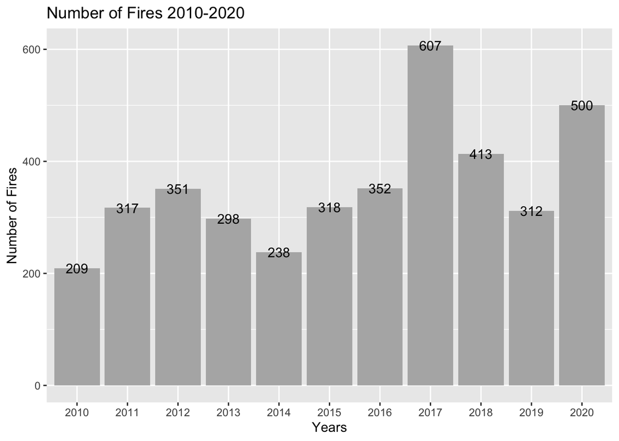

```r
# Number of fires 2010-2020
# Note the requirements for fires to be reported in this data set from 2010 on
num_fires <- fires %>% filter(year >= "2010") %>%
  group_by(year) %>%
  summarise(num=n())
num_fires$year <- as.character(num_fires$year)
ggplot(num_fires, aes(x=year, y=num)) +
  geom_bar(stat="identity", fill="gray70") +
  geom_text(aes(label=num)) +
  xlab("Years") + ylab("Number of Fires") +
  ggtitle("Number of Fires 2010-2020")
```

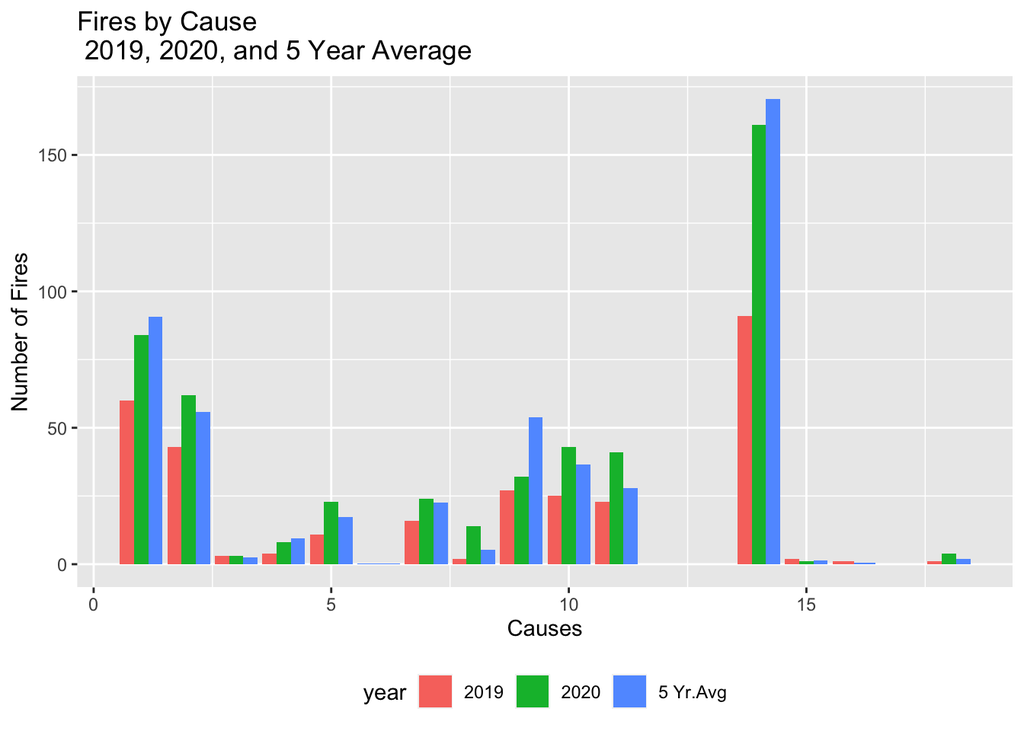

```r
# Fires by Cause 2020, 2019, 5 year avg
# Cause, num fires, year
cause2020 <- fires %>%
  select(cause, year) %>%
  filter(year == "2020") %>%
  group_by(cause) %>%
  summarise(num_fires = n(), year="2020")
cause2019 <- fires %>%
  select(cause, year) %>%
  filter(year == "2019") %>%
  group_by(cause) %>%
  summarise(num_fires = n(), year="2019")
cause_avg <- fires %>%
  select(cause, year) %>%
  filter(year >= "2015") %>%
  group_by(cause) %>%
  summarise(num_fires = (n()/5), year="5 Yr.Avg")
df <- bind_rows(cause2020, cause2019)
df <- bind_rows(df, cause_avg)
# I would like to add labels of what causes are but that's no fun with ggplot
ggplot(df, aes(fill=year, y=num_fires, x=cause)) +
  geom_bar(position="dodge", stat="identity") +
  xlab("Causes") + ylab("Number of Fires") +
  ggtitle("Fires by Cause \n 2019, 2020, and 5 Year Average") +
  theme(legend.position="bottom")
```

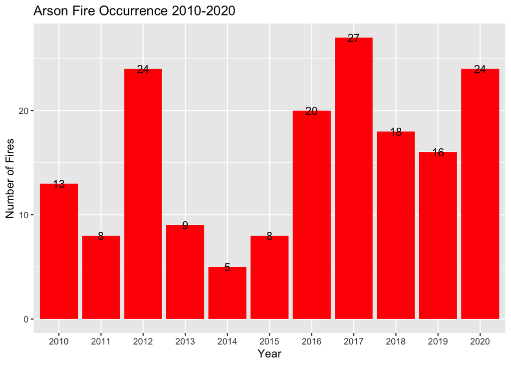

```r
library(lubridate)
# Arson occurrence and Acres Burned last decade
arson_num <- fires %>%
  select(cause, year) %>%
  filter(cause == 7 & year >= "2010") %>%
  group_by(year) %>%
  summarise(fires = n())
arson_size <- fires %>%
  select(cause, year, report_ac) %>%
  filter(cause == 7 & !is.na(report_ac) & year >= "2010") %>%
  group_by(year) %>%
  summarise(report_ac = sum(report_ac))
arson <- merge(arson_num, arson_size)
arson$year <- as.character(arson$year)
arson$report_ac <- as.integer(arson$report_ac)
ggplot(arson, aes(x=year, y=fires)) +
  geom_bar(stat="identity", fill="red") +
  geom_text(aes(label=fires)) +
  xlab("Year") + ylab("Number of Fires") +
  ggtitle("Arson Fire Occurrence 2010-2020")
```

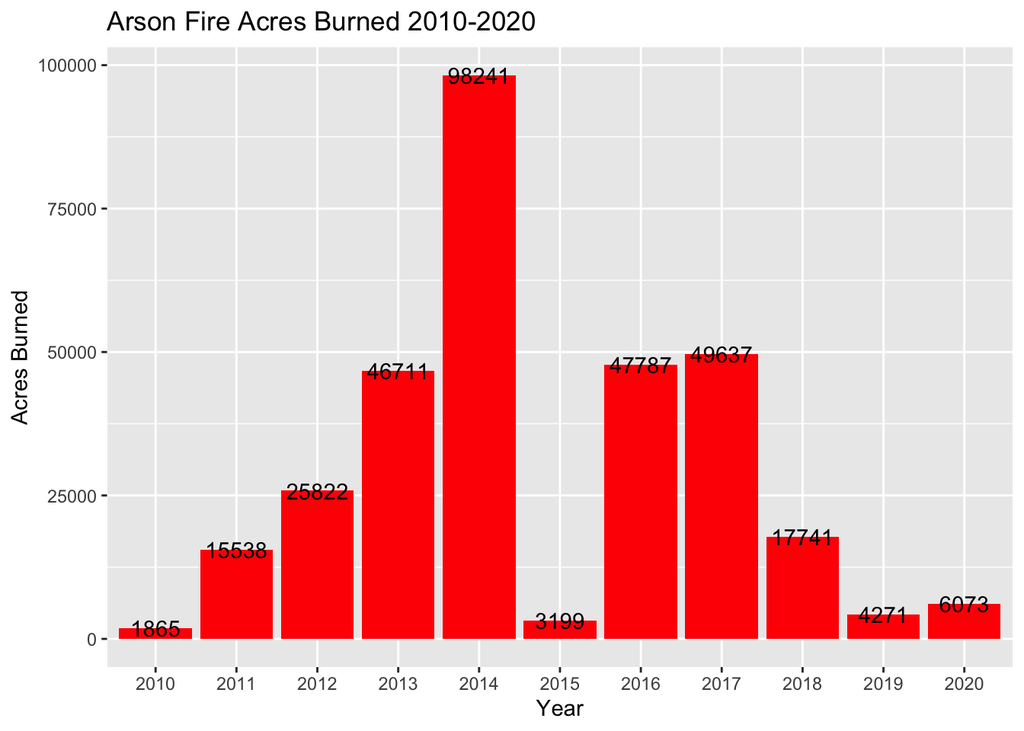

```r
ggplot(arson, aes(x=year, y=report_ac)) +
  geom_bar(stat="identity", fill="red") +
  geom_text(aes(label=report_ac)) +
  xlab("Year") + ylab("Acres Burned") +
  ggtitle("Arson Fire Acres Burned 2010-2020")
```

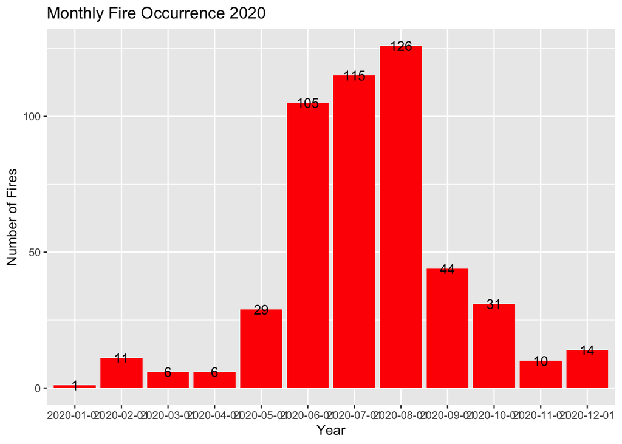

```r
# Number of fires and acres burned by month for 2020
df <- fires %>%
  filter(year == "2020")
df$alarm_date <- as.Date(df$alarm_date, "%Y/%m/%d")
num_fires_month <- df %>%
  group_by(month = floor_date(alarm_date, "month")) %>%
  summarize(fires = n()) %>%
  filter(month < "2021-01-01")
acres_month <- df %>%
  group_by(month = floor_date(alarm_date, "month")) %>%
  filter(!is.na(report_ac)) %>%
  summarize(report_ac = sum(report_ac)) %>%
  filter(month < "2021-01-01")
monthly_fires <- merge(num_fires_month, acres_month, all=TRUE)
monthly_fires$month <- as.character(monthly_fires$month)
monthly_fires$report_ac <- as.integer(monthly_fires$report_ac)

ggplot(monthly_fires, aes(x=month, y=fires)) +
  geom_bar(stat="identity", fill="red") +
  geom_text(aes(label=fires)) +
  xlab("Year") + ylab("Number of Fires") +
  ggtitle("Monthly Fire Occurrence 2020")
```

[figure not shown]

```r
ggplot(monthly_fires, aes(x=month, y=report_ac)) +
  geom_bar(stat="identity", fill="red") +
  geom_text(aes(label=report_ac)) +
  xlab("Year") + ylab("Acres Burned") +
  ggtitle("Acres Burned by Month 2010")
```

```r
# My brother has been CAL FIRE in Santa Clara County (SCU) since 2020
cal_fire <- fires %>%
  select(agency, unit_id) %>%
  filter(agency == "CDF")
cal_fire_units <- unique(cal_fire$unit_id)

fires %>% filter(year == "2020" & unit_id == "SCU")
```

```
##   year state agency unit_id   fire_name  inc_num             alarm_date
## 1 2020    CA    CDF     SCU SCU COMPLEX 00005740 2020/08/16 00:00:00+00
## 2 2020    CA    CDF     SCU        PARK 00004669 2020/07/04 00:00:00+00
## 3 2020    CA    CDF     SCU       CREWS 00004686 2020/07/05 00:00:00+00
##                cont_date cause comments report_ac gis_acres c_method objective
## 1 2020/09/11 00:00:00+00     1                 NA    396399        2         1
## 2 2020/07/10 00:00:00+00     2                 NA       343        2         1
## 3 2020/07/15 00:00:00+00     8                 NA      5513        2         1
##   fire_num shape_length  shape_area
## 1            634336.339 -2545883719
## 2              7516.045    -2186241
## 3             45170.979   -35060829
```

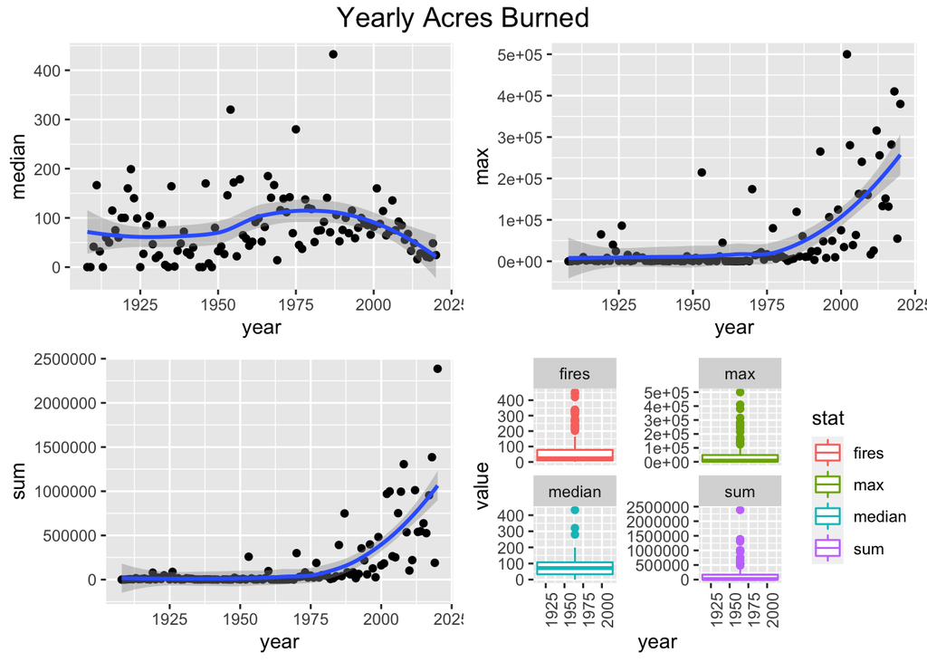

```r
#This is my first attempt here at tidying data. Only up from here.
#Lets see if median fire is increasing every year
fire_yr <- fires %>% filter(report_ac != "" & !is.na(report_ac)) %>%
  group_by(year) %>%
  summarise(median = median(report_ac), max = max(report_ac),
            sum=sum(report_ac), fires = n())
plot <- ggplot(fire_yr, aes(x=year))
tidy <- fire_yr %>% gather("stat", "value", -year)
median <- plot + geom_point(aes(y=median)) + geom_smooth(aes(y=median))
max <- plot + geom_point(aes(y=max)) + geom_smooth(aes(y = max))
sum <- plot + geom_point(aes(y=sum)) + geom_smooth(aes(y=sum))
box <- ggplot(tidy, aes(x=year, y=value)) +
  geom_boxplot(aes(color = stat)) +
  facet_wrap(~stat, scales="free_y") +
  theme(axis.text.x = element_text(angle = 90))
grid.arrange(median, max, sum, box, nrow=2,
             top=textGrob("Yearly Acres Burned", gp=gpar(fontsize=15,font=1)))
```

```r
#Collection methods
first_yr_c_method <- fires %>% select(year, c_method) %>%
  drop_na() %>% arrange(year) %>% head()
total_c <- table(fires$c_method)
labels <- c("GPS Ground", "GPS Air", "Infared", "Other Imagery",
            "Photo Interpretation", "Hand Drawn", "Mixed Collection Tools",
            "Unknown")
df <- data.frame(Method = labels, count = as.vector(total_c))
df
```

```
##                   Method count
## 1             GPS Ground  3302
## 2                GPS Air   585
## 3                Infared   185
## 4          Other Imagery   165
## 5   Photo Interpretation    89
## 6             Hand Drawn  1085
## 7 Mixed Collection Tools   768
## 8                Unknown  2917
```

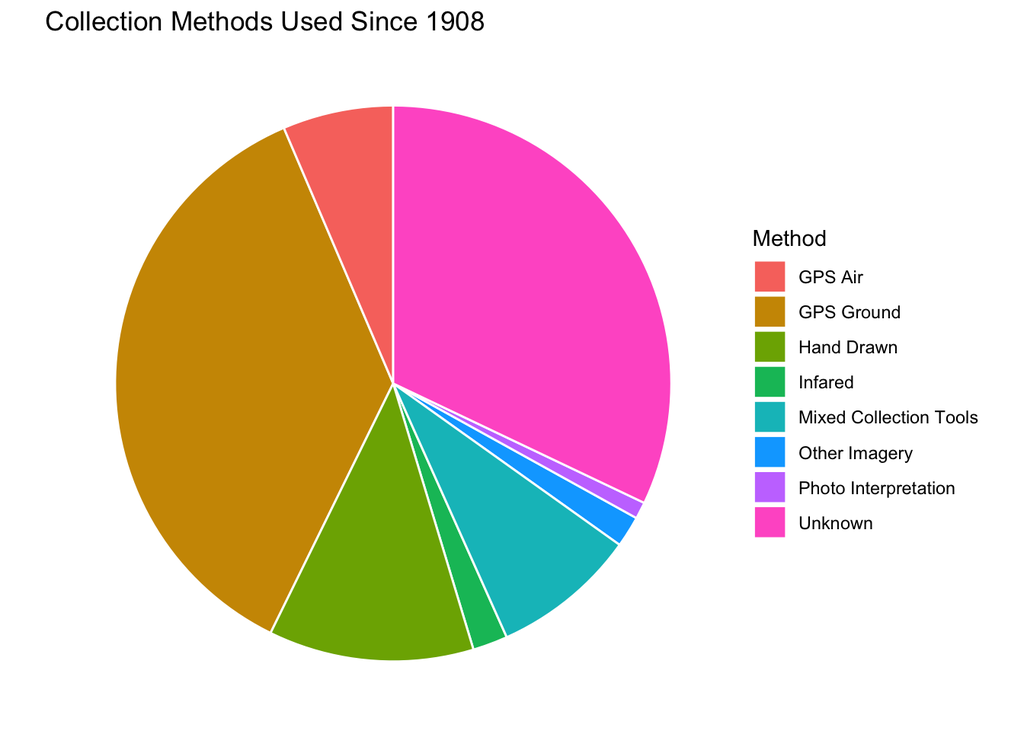

```r
pie <- ggplot(df, aes(x="", y=count, fill=Method)) +
  geom_bar(stat="identity", width=1, color="white") +
  coord_polar("y", start=0) + theme_void()
pie + ggtitle(paste("Collection Methods Used Since", first_yr_c_method$year[1]))
```

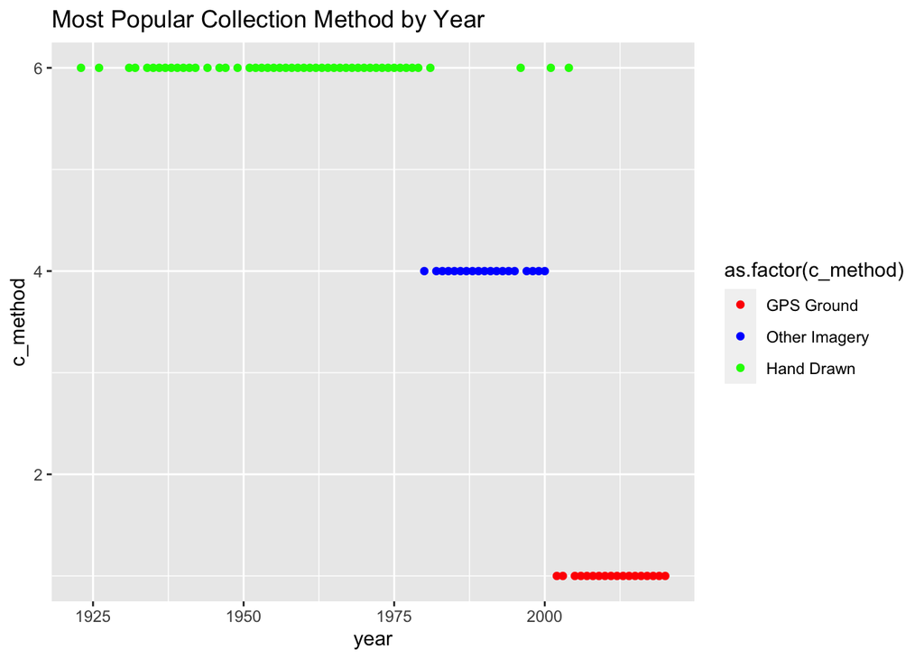

```r
#How collection methods have changed over the years
ggplot(c_method_yr, aes(x = year, y=c_method, color=as.factor(c_method))) +
  geom_point() +
  ggtitle("Most Popular Collection Method by Year") +
  scale_color_manual(labels = c("GPS Ground", "Other Imagery", "Hand Drawn"),
                     values = c("red", "blue", "green"))
```

## Conclusion

EDA was harder than I thought it would be. I spent too much time being picky about how I wanted the graphs look. It was difficult to adjust the labels of the legends. I also found I struggled to understand the data when I thought I had a good grip on it from the previous data analytic stage. I also took on more than I could when trying to analyze the entire data set. I will continue this but using just 2019 before I move on to harder EDA. I also would like to make better use of facet wraps and grids for functions but I need to tidy my data better. It offers unique perspectives and makes it easier to understand large data. I would like to analyze the data using more categorical variables or binomial variables like agency and cause_code I do not want to use grid.arrange because it was not talked about during lectures. One more thing I would like to do is take advantage of the GIS data by marking areas on a map of California. I have made huge strides from this project and come away with a great appreciation for tidyverse.